## Online interactive Jupyter notebook as a supplement for:

# Predicting Lyme Disease from Patients’ Peripheral Blood Mononuclear Cells Profiled with RNA-sequencing

**Daniel J.B. Clarke<sup>1,+</sup>, Alison W. Rebman<sup>2,+</sup>, Allison Bailey<sup>1</sup>, Megan L. Wojciechowicz<sup>1</sup>, Sherry L. Jenkins<sup>1</sup>, John E. Evangelista<sup>1</sup>, Matteo Danieletto<sup>3</sup>, Jinshui Fan<sup>2</sup>, Mark Eshoo<sup>4</sup>, Michael Mosel<sup>5</sup>, William Robinson<sup>6</sup>, Nitya Ramadoss<sup>6</sup>, Jason Bobe<sup>3</sup>, Mark J. Soloski<sup>2,*</sup>, John N. Aucott<sup>2,*</sup>, Avi Ma’ayan<sup>1,*</sup>**

<sup>1</sup> Department of Pharmacological Sciences; Mount Sinai Center for Bioinformatics; Icahn School of Medicine at Mount Sinai, One Gustave L. Levy Place, Box 1603, New York, NY 10029, USA  
<sup>2</sup> Lyme Disease Research Center, Division of Rheumatology, Department of Medicine, Johns Hopkins University School of Medicine, Baltimore, MD, United States  
<sup>3</sup> Department of Genetics and Genomic Sciences; Icahn School of Medicine at Mount Sinai, One Gustave L. Levy Place, Box 1498, New York, NY 10029, USA  
<sup>4</sup> BlueArc Biosciences, San Diego  
<sup>5</sup> Janus-I Science Inc. Vista, California  
<sup>6</sup> Department of Medicine, Division of Immunology and Rheumatology, Stanford University School of Medicine  
<sup>+</sup> Contributed equally

## Install dependencies

```
cat > requirements.txt << EOF
colour
maayanlab_bioinformatics@git+https://github.com/Maayanlab/maayanlab-bioinformatics.git@v0.1.3
matplotlib
matplotlib_venn
numpy
pandas
rpy2
scikit-learn
seaborn
statannot
umap
EOF

pip3 install -r requirements.txt

cat > setup.R << EOF
if (!requireNamespace("BiocManager", quietly = TRUE))
  install.packages("BiocManager")
BiocManager::install("sva")
BiocManager::install("bladderbatch")
EOF

Rscript setup.R
```

```python
# dataframe utilities
import numpy as np
import pandas as pd
from maayanlab_bioinformatics.utils import merge
# plotting utilities
import matplotlib.pyplot as plt
import seaborn as sns
from matplotlib_venn import venn2
# utility for adding statistics to boxplots
from statannot import add_stat_annotation
# color generation utilities
from colour import Color
# bioinformatics analysis tools
from maayanlab_bioinformatics.dge import characteristic_direction
from maayanlab_bioinformatics.harmonization import transcripts_to_genes
# data analysis
import scipy.stats as sp_stats
from sklearn.metrics import silhouette_score
from sklearn.cluster import KMeans
from umap import UMAP
from maayanlab_bioinformatics.normalization import quantile_normalize, log2_normalize, zscore_normalize
from rpy2.robjects import r, numpy2ri, pandas2ri
numpy2ri.activate()
pandas2ri.activate()

r('''
library(sva)
library(bladderbatch)
''')
# classification
from sklearn.dummy import DummyClassifier
from sklearn.linear_model import LogisticRegressionCV
from sklearn.ensemble import RandomForestClassifier
from sklearn.feature_selection import SelectFromModel, SelectKBest
from sklearn.metrics import roc_curve, precision_recall_curve, auc
from sklearn.model_selection import train_test_split
from sklearn.preprocessing import StandardScaler
from sklearn.pipeline import Pipeline
```

[output not shown]

## Load data & prepare clinical metadata

```python
# RNAseq expression count matrix for each patient
df_lm2 = pd.read_csv('../data/LM_Slice2_Slice3_data/LM2_Genetic_Entrez.csv', index_col=0)
# Recorded clinical data about each patient
df_lm2_clinical = pd.read_csv('../data/LM_Slice2_Slice3_data/LM2_Clinical_Entrez.csv', index_col=0)
# Recorded PTLDS patient status
df_lm2_ptlds = pd.read_csv('../data/LM_Slice2_Slice3_data/LM2 ptlds 09.09.19.csv', index_col=0)
```

```python
# Convert PTLDS status into binary indicator:
#  ptlds_anysign: any reported symptom that could eventually lead
#   to a PTLDS diagnosis but alone would *not* be considered PTLDS
#  ptlds_complete: all indications that this **is** to be considered
#   a case of PTLDS.
df_lm2_ptlds['ptlds_anysign'] = df_lm2_ptlds.apply(lambda rec: rec['pls_merge5'] in {'1', '2', '3'} or rec['pls_merge6'] in {'1', '2', '3'}, axis=1).astype(int)
df_lm2_ptlds['ptlds_complete'] = df_lm2_ptlds.apply(lambda rec: rec['pls_merge5'] in {'3'} or rec['pls_merge6'] in {'3'}, axis=1).astype(int)
ptlds_anysign_lookup = df_lm2_ptlds['ptlds_anysign'].to_dict()
ptlds_complete_lookup = df_lm2_ptlds['ptlds_complete'].to_dict()
df_lm2_clinical['ptlds_anysign'] = df_lm2_clinical['pid'].apply(ptlds_anysign_lookup.get).fillna(0)
df_lm2_clinical['ptlds_complete'] = df_lm2_clinical['pid'].apply(ptlds_complete_lookup.get).fillna(0)
```

```python
# Improve labeling for clinical metadata in charts
df_lm2_clinical['Subject Type'] = df_lm2_clinical['type_subject'].replace({
  0: 'Control',
  1: 'Case',
})

def visit_converter(rec):
    ''' Meaningfully group visits together at time periods, removing gaps
    For more information about what each "visit" number means, see the paper.
    '''
    v = rec['orig_id'].split('-')[0]
    if v == '04':
        return {
            '1': 1,
            '2': 2,
            '5': 3,
            '6': 4,
        }[str(rec['visit'])]
    elif v == '09':
        return {
            '1': 1,
            '5': 3,
        }[str(rec['visit'])]
    elif v == '02':
        return {
            '1': 1,
            '2': 3,
            '3': 4,
            '4': 5,
        }[str(rec['visit'])]
    raise Exception('Unhandled orig_id type')

df_lm2_clinical['Visit'] = df_lm2_clinical.apply(visit_converter, axis=1)

def ibis_converter(rec):
  if rec['ibis_skin'] == 0 and rec['ibis_blood'] == 0:
    return 'PCR/ESI-MS skin (-) / blood (-)'
  elif rec['ibis_skin'] == 1 and rec['ibis_blood'] == 1:
    return 'PCR/ESI-MS skin (+) / blood (+)'
  elif rec['ibis_skin'] == 1 and rec['ibis_blood'] == 0:
    return 'PCR/ESI-MS skin (+) / blood (-)'
  else:
    return 'PCR/ESI-MS not done'

df_lm2_clinical['PCR/ESI-MS'] = df_lm2_clinical.apply(ibis_converter, axis=1)

df_lm2_clinical['Batch'] = df_lm2_clinical['batch'].astype(str)
df_lm2_clinical['Season'] = df_lm2_clinical['season_yr'].astype(str)
```

## UMAP analysis

We normalize the prepared LymeMIND2 expression counts matrix and perform UMAP to visualize patient expression relationships in a 2d manifold.

```python
df_lm2_norm = quantile_normalize(
    zscore_normalize(
        log2_normalize(
          df_lm2[df_lm2.mean(axis=1) > 5] + 1
        )
    )
)

lm2_norm_umap = UMAP(n_components=2, random_state=41)

df_lm2_norm_umap = pd.DataFrame(
    lm2_norm_umap.fit_transform(df_lm2_norm.values.T),
    index=df_lm2_norm.T.index, columns=['UMAP-1', 'UMAP-2'],
)
```

### Figure 1.A

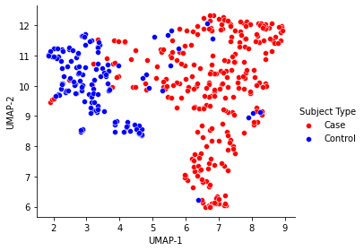

```python
patient_colors = {
  'Control': 'blue',
  'Case': 'red',
}
sns.FacetGrid(
    merge(
        df_lm2_norm_umap,
        df_lm2_clinical,
    ),
    hue='Subject Type',
    palette=patient_colors,
    height=4,
    aspect=1.2,
).map(
    sns.scatterplot,
    df_lm2_norm_umap.columns[0],
    df_lm2_norm_umap.columns[1],
).add_legend()
# plt.savefig('figures/umap_subject_type.pdf', dpi=300)
# plt.savefig('figures/umap_subject_type.png', dpi=300)
```

## Silohette Analysis

We perform silohette analysis to identify optimal data-driven cluster assignment of patient expression data

```python
silhouette_scores = {}
for n in range(2, 12):
    y_pred = KMeans(n_clusters=n, random_state=6).fit_predict(df_lm2_norm_umap.values)
    silhouette_scores[n] = silhouette_score(df_lm2_norm_umap.values, y_pred)

silhouette_scores = pd.DataFrame([
    {'N Clusters': k, 'Silhouette Score': v}
    for k, v in silhouette_scores.items()
])
best = silhouette_scores.sort_values('Silhouette Score').iloc[-1]
km = KMeans(n_clusters=int(best['N Clusters']), random_state=6)
df_lm2_norm_km = pd.DataFrame({
    'Cluster': [
        '%d' % (c)
        for c in km.fit_predict(df_lm2_norm_umap.values)
    ]
}, index=df_lm2_norm.T.index)
```

### Figure 1.B: Silohette Scores

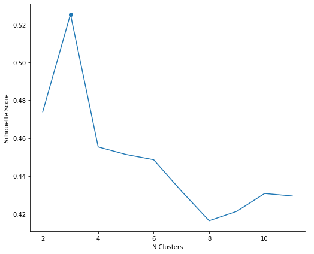

```python
g = sns.FacetGrid(
    silhouette_scores,
    height=6,
    aspect=1.2,
).map(
    plt.plot,
    'N Clusters',
    'Silhouette Score',
)
plt.scatter([best['N Clusters']], [best['Silhouette Score']], label='Best')
g.add_legend()
```

### Figure 1.C: Clustered UMAP

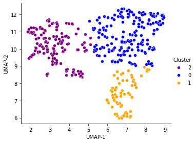

```python
cluster_colors = {
    '0': 'blue',
    '1': 'orange',
    '2': 'purple',
}

sns.FacetGrid(
    merge(
        df_lm2_norm_umap,
        df_lm2_norm_km,
        df_lm2_clinical,
    ),
    hue='Cluster',
    palette=cluster_colors,
    height=4,
    aspect=1.2,
).map(
    sns.scatterplot,
    df_lm2_norm_umap.columns[0],
    df_lm2_norm_umap.columns[1],
).add_legend()
```

## Time Series Analysis

We try to visualize how patients move through the manifold over time

### Figure 1.D

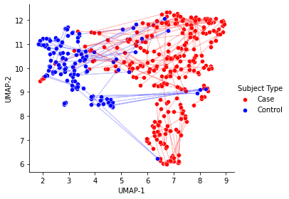

```python
g = sns.FacetGrid(
    merge(
        df_lm2_norm_umap,
        df_lm2_clinical,
    ),
    hue='Subject Type',
    palette=patient_colors,
    height=4,
    aspect=1.2,
).map(
    sns.scatterplot,
    df_lm2_norm_umap.columns[0],
    df_lm2_norm_umap.columns[1],
).add_legend()

for patient, samples in df_lm2_clinical.groupby('pid'):
    x, y = zip(*df_lm2_norm_umap.loc[
        samples.sort_values('Visit').index, [df_lm2_norm_umap.columns[0], df_lm2_norm_umap.columns[1]]
    ].values)
    for (x1, y1), (x2, y2) in zip(zip(x[:-1], y[:-1]), zip(x[1:], y[1:])):
        g.ax.arrow(
            x1, y1, x2 - x1, y2 - y1,
            label=patient,
            color=patient_colors.get(samples.loc[:, 'Subject Type'].iloc[0]),
            alpha=0.2,
        )
```

### Figure 1.E: Movement of controls that exit the 'control' cluster

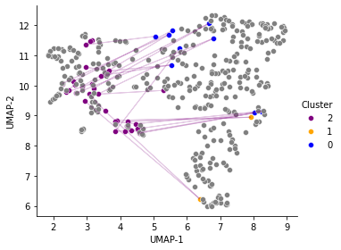

```python
g = merge(
    df_lm2_clinical,
    df_lm2_norm_km,
)
g_pids = g[g['Subject Type'] == 'Control'].groupby('pid')['Cluster'].unique()
pids = list(g_pids[g_pids.apply(lambda c: '0' in c or '1' in c)].index)

g = merge(
    df_lm2_clinical[df_lm2_clinical['pid'].isin(pids)],
    df_lm2_norm_km,
    df_lm2_norm_umap,
)
_ = sns.FacetGrid(
    g,
    hue='Cluster',
    palette=cluster_colors,
    height=4,
    aspect=1.2,
).map(
    sns.scatterplot,
    df_lm2_norm_umap.columns[0],
    df_lm2_norm_umap.columns[1],
).add_legend()

for patient, samples in g.groupby('pid'):
    x, y = zip(*df_lm2_norm_umap.loc[
        samples.sort_values('Visit').index, [
            df_lm2_norm_umap.columns[0], df_lm2_norm_umap.columns[1]
        ]
    ].values)
    for (x1, y1), (x2, y2) in zip(zip(x[:-1], y[:-1]), zip(x[1:], y[1:])):
        _.ax.arrow(
            x1, y1, x2 - x1, y2 - y1,
            label=patient,
            color=cluster_colors.get(samples.loc[:, 'Cluster'].iloc[0]),
            alpha=0.2,
        )

sns.scatterplot(
    data=df_lm2_norm_umap.loc[df_lm2_norm_umap.index.difference(g.index)],
    x=df_lm2_norm_umap.columns[0],
    y=df_lm2_norm_umap.columns[1],
    color='grey',
    ax=_.ax,
    legend=False,
)
```

### Figure 1.F: Movement of cases that entered the control cluster at some point

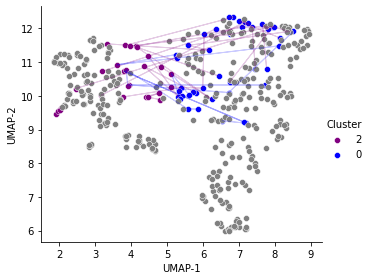

```python
g = merge(
    df_lm2_clinical,
    df_lm2_norm_km,
)
g_pids = g[g['Subject Type'] == 'Case'].groupby('pid')['Cluster'].unique()
pids = list(g_pids[g_pids.apply(lambda c: '2' in c)].index)

g = merge(
    df_lm2_clinical[df_lm2_clinical['pid'].isin(pids)],
    df_lm2_norm_km,
    df_lm2_norm_umap,
)
_ = sns.FacetGrid(
    g,
    hue='Cluster',
    palette=cluster_colors,
    height=4,
    aspect=1.2,
).map(
    sns.scatterplot,
    df_lm2_norm_umap.columns[0],
    df_lm2_norm_umap.columns[1],
).add_legend()

for patient, samples in g.groupby('pid'):
    x, y = zip(*df_lm2_norm_umap.loc[
        samples.sort_values('Visit').index, [
            df_lm2_norm_umap.columns[0], df_lm2_norm_umap.columns[1]
        ]
    ].values)
    for (x1, y1), (x2, y2) in zip(zip(x[:-1], y[:-1]), zip(x[1:], y[1:])):
        _.ax.arrow(
            x1, y1, x2 - x1, y2 - y1,
            label=patient,
            color=cluster_colors.get(samples.loc[:, 'Cluster'].iloc[0]),
            alpha=0.2,
        )

sns.scatterplot(
    data=df_lm2_norm_umap.loc[df_lm2_norm_umap.index.difference(g.index)],
    x=df_lm2_norm_umap.columns[0],
    y=df_lm2_norm_umap.columns[1],
    color='grey',
    ax=_.ax,
    legend=False,
)
```

### Figure 1.G: Case movement for patients who entered cluster 1 at some point

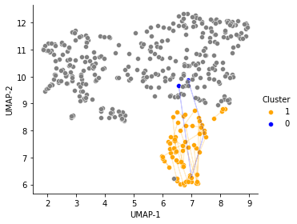

```python
g = merge(
    df_lm2_clinical,
    df_lm2_norm_km,
    df_lm2_norm_umap,
)
g_pids = g[g['Subject Type'] == 'Case'].groupby('pid')['Cluster'].unique()
pids = list(g_pids[g_pids.apply(lambda c: '1' in c)].index)

g = merge(
    df_lm2_clinical[df_lm2_clinical['pid'].isin(pids)],
    df_lm2_norm_km,
    df_lm2_norm_umap,
)
_ = sns.FacetGrid(
    g,
    hue='Cluster',
    palette=cluster_colors,
    height=4,
    aspect=1.2,
).map(
    sns.scatterplot,
    df_lm2_norm_umap.columns[0],
    df_lm2_norm_umap.columns[1],
).add_legend()

for patient, samples in g.groupby('pid'):
    x, y = zip(*df_lm2_norm_umap.loc[
        samples.sort_values('Visit').index, [
            df_lm2_norm_umap.columns[0], df_lm2_norm_umap.columns[1]
        ]
    ].values)
    for (x1, y1), (x2, y2) in zip(zip(x[:-1], y[:-1]), zip(x[1:], y[1:])):
        _.ax.arrow(
            x1, y1, x2 - x1, y2 - y1,
            label=patient,
            color=cluster_colors.get(samples.loc[:, 'Cluster'].iloc[0]),
            alpha=0.2,
        )

sns.scatterplot(
    data=df_lm2_norm_umap.loc[df_lm2_norm_umap.index.difference(g.index)],
    x=df_lm2_norm_umap.columns[0],
    y=df_lm2_norm_umap.columns[1],
    color='grey',
    ax=_.ax,
    legend=False,
)
```

### Figure 1.H: Overall subject-cluster membership over time

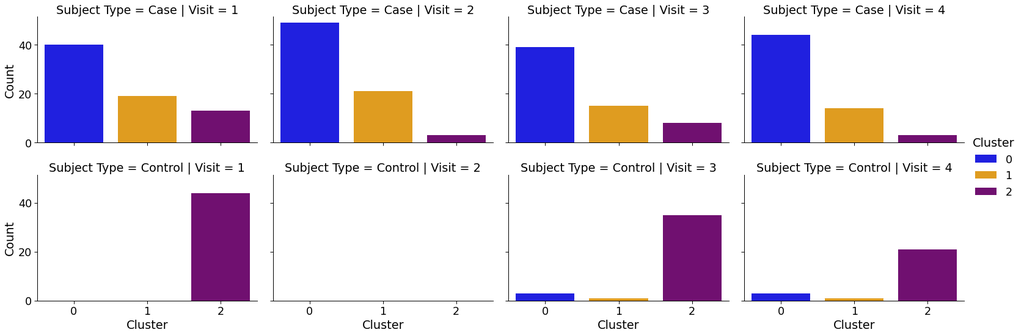

```python
g = merge(
    df_lm2_clinical,
    df_lm2_norm_km,
).groupby(['Visit', 'Subject Type', 'Cluster'])['pid'].describe().rename({ 'count': 'Count' }, axis=1)
g = g.loc[pd.IndexSlice[[1, 2, 3, 4], :]]
sns.set_context('paper', font_scale=2)
sns.FacetGrid(
    g.reset_index(),
    hue='Cluster',
    col='Visit',
    row='Subject Type',
    palette=cluster_colors,
    height=4,
    aspect=1.4,
).map(
    sns.barplot,
    'Cluster',
    'Count',
    order=['0', '1', '2'],
).add_legend()
```

## Figure 2: PCI/ESI-MS status

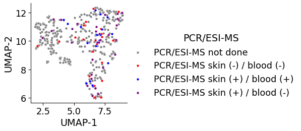

```python
sns.FacetGrid(
    merge(
        df_lm2_clinical,
        df_lm2_norm_umap,
    ),
    hue='PCR/ESI-MS',
    palette={
        'PCR/ESI-MS skin (+) / blood (+)': 'blue',
        'PCR/ESI-MS skin (+) / blood (-)': 'purple',
        'PCR/ESI-MS skin (-) / blood (-)': 'red',
        'PCR/ESI-MS not done': 'grey',
    },
    height=4,
    aspect=1.2,
).map(
    sns.scatterplot,
    df_lm2_norm_umap.columns[0],
    df_lm2_norm_umap.columns[1],
).add_legend()
```

## Figure 3.A: Color by batch

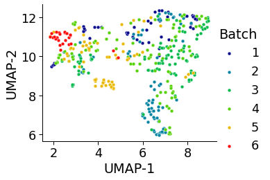

```python
start = 1
end = 6
palette = {
    str(k): (v.red, v.green, v.blue)
    for k, v in zip(
        range(start, end + 1),
        Color('darkblue').range_to(Color('red'), end - start + 1)
    )
}

sns.FacetGrid(
    merge(
        df_lm2_norm_umap,
        df_lm2_norm_km,
        df_lm2_clinical,
    ),
    hue='Batch',
    palette=palette,
    height=4,
    aspect=1.2,
).map(
    sns.scatterplot,
    df_lm2_norm_umap.columns[0],
    df_lm2_norm_umap.columns[1],
).add_legend()
```

## Figure 3.B: Color by year

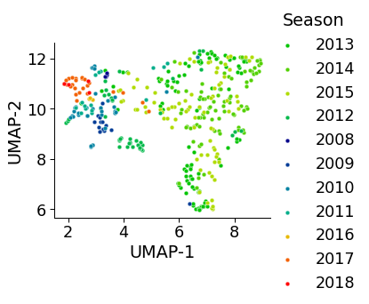

```python
start = 2008
end = 2018
palette = {
    str(k): (v.red, v.green, v.blue)
    for k, v in zip(
        range(start, end + 1),
        Color('darkblue').range_to(Color('red'), end - start + 1)
    )
}

sns.FacetGrid(
    merge(
        df_lm2_norm_umap,
        df_lm2_norm_km,
        df_lm2_clinical,
    ),
    hue='Season',
    palette=palette,
    height=4,
    aspect=1.2,
).map(
    sns.scatterplot,
    df_lm2_norm_umap.columns[0],
    df_lm2_norm_umap.columns[1],
).add_legend()
```

## Enrichment Analysis via Characteristic Direction

```python
df_lm2_controls = quantile_normalize(df_lm2).loc[
    :, list(df_lm2_clinical[df_lm2_clinical['type_subject'] == 0].index),
]
df_lm2_cases = quantile_normalize(df_lm2).loc[
    :, list(df_lm2_clinical[df_lm2_clinical['type_subject'] == 1].index),
]
chdir_results = characteristic_direction(
    df_lm2_controls,
    df_lm2_cases,
    sort=False,
)['CD-coefficient']

top_results = chdir_results.loc[
    list(chdir_results.abs().sort_values(ascending=False).iloc[:50].index)
].sort_values(ascending=False)
up_genes = list(top_results[top_results > 0].index)
down_genes = list(top_results[top_results < 0].index)
```

### Figure 4: Characteristic Direction DEGs

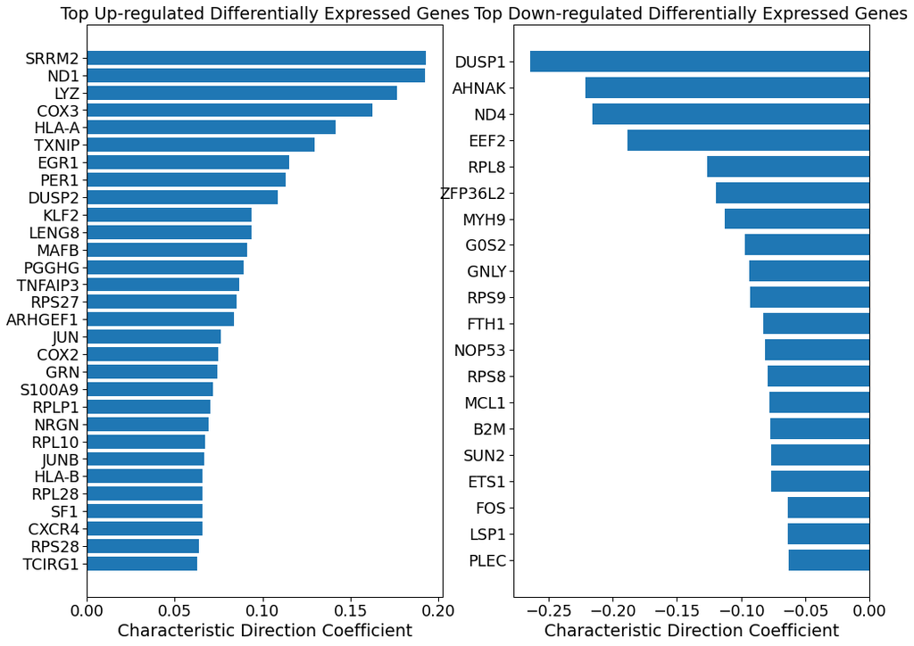

```python
fig, (ax1, ax2) = plt.subplots(1, 2, figsize=(16, 12))
ax1.set_title('Top Up-regulated Differentially Expressed Genes')
ax1.barh(
    y=top_results[top_results > 0].sort_values(ascending=True).index,
    width=chdir_results.loc[top_results[top_results > 0].sort_values(ascending=True).index],
)
ax1.set_xlabel('Characteristic Direction Coefficient')
ax2.set_title('Top Down-regulated Differentially Expressed Genes')
ax2.barh(
    y=top_results[top_results < 0].index,
    width=chdir_results.loc[top_results[top_results < 0].index]
)
ax2.set_xlabel('Characteristic Direction Coefficient')
# plt.savefig('figures/differentially_expressed_genes_chdir.pdf', dpi=300)
# plt.savefig('figures/differentially_expressed_genes_chdir.png', dpi=300)
plt.show()
```

## Cibersort Analysis

Processed via https://cibersort.stanford.edu/

```python
df_lm2_cibersort = pd.read_csv('../data/CIBERSORT.Output_Job11-LM2.csv', index_col=0)
df_lm2_cibersort = df_lm2_cibersort.drop(['RMSE', 'P-value', 'Pearson Correlation'], axis=1)
```

### Figure 6.A

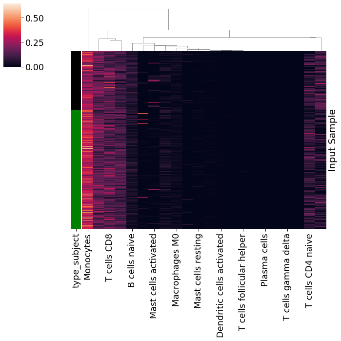

```python
sorted_samp = list(df_lm2_clinical.loc[list(df_lm2_cibersort.index), 'type_subject'].sort_values().index)
g = sns.clustermap(
    df_lm2_cibersort.loc[sorted_samp],
    row_colors=df_lm2_clinical.loc[sorted_samp, 'type_subject'].apply(
        lambda r: 'green' if r == 1 else 'black',
    ),
    row_cluster=False,
    yticklabels=[],
)
```

### Figure 6.B, 6.C, 6.D

```
0 v.s. 1: Welch's t-test independent samples with Bonferroni correction, P_val=6.854e-13 stat=7.575e+00
```

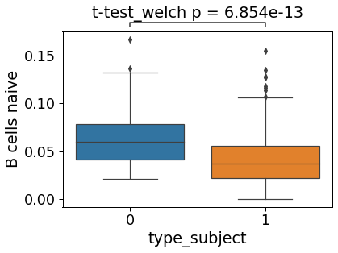

```
0 v.s. 1: Welch's t-test independent samples with Bonferroni correction, P_val=2.417e-02 stat=-2.268e+00
```

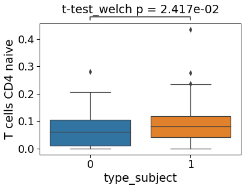

```
0 v.s. 1: Welch's t-test independent samples with Bonferroni correction, P_val=3.479e-17 stat=9.139e+00
```

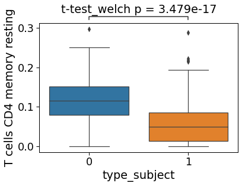

```
0 v.s. 1: Welch's t-test independent samples with Bonferroni correction, P_val=2.193e-07 stat=-5.325e+00
```

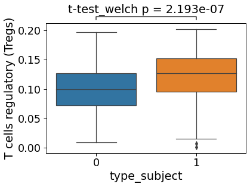

```
0 v.s. 1: Welch's t-test independent samples with Bonferroni correction, P_val=nan stat=nan
```

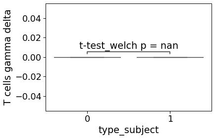

```
0 v.s. 1: Welch's t-test independent samples with Bonferroni correction, P_val=2.515e-02 stat=-2.252e+00
```

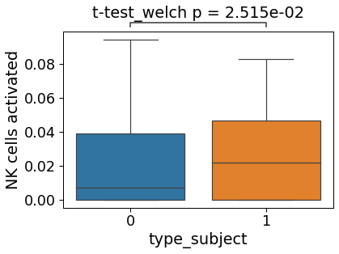

```
0 v.s. 1: Welch's t-test independent samples with Bonferroni correction, P_val=1.666e-08 stat=-5.812e+00
```

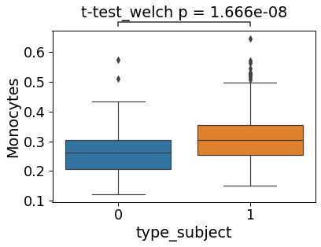

```
0 v.s. 1: Welch's t-test independent samples with Bonferroni correction, P_val=3.729e-02 stat=2.093e+00
```

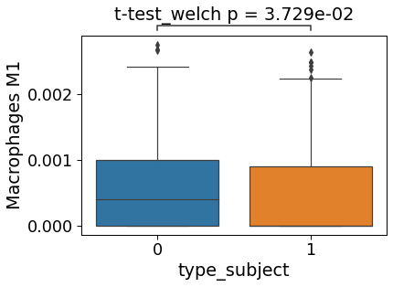

```
0 v.s. 1: Welch's t-test independent samples with Bonferroni correction, P_val=2.432e-03 stat=-3.056e+00
```

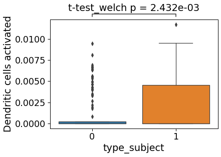

```
0 v.s. 1: Welch's t-test independent samples with Bonferroni correction, P_val=2.999e-03 stat=3.020e+00
```

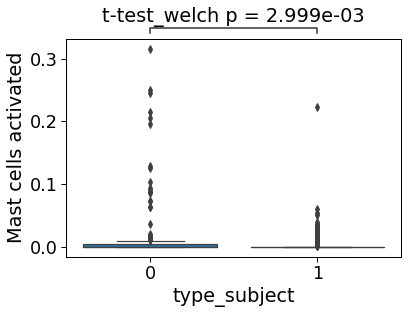

```
0 v.s. 1: Welch's t-test independent samples with Bonferroni correction, P_val=7.238e-06 stat=-4.562e+00
```

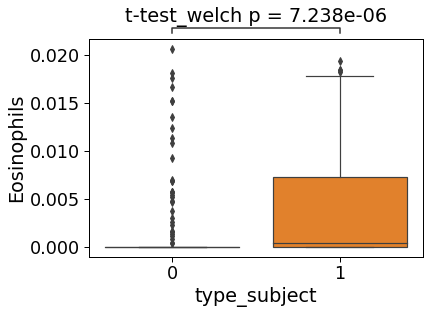

```python
data = merge(
    df_lm2_cibersort,
    df_lm2_clinical[['type_subject']].astype(str),
)
for col in df_lm2_cibersort.columns:
    x='type_subject'
    y=col
    order=['0', '1']
    pval = sp_stats.ttest_ind(
      data[data[x] == '0'].loc[:, y],
      data[data[x] == '1'].loc[:, y]
    ).pvalue
    if pval >= 0.05:
      continue

    ax = sns.boxplot(data=data, x=x, y=y, order=order)
    test_results = add_stat_annotation(ax, data=data, x=x, y=y, order=order,
                                       box_pairs=[('0', '1')],
                                       test='t-test_welch', text_format='full',
                                       loc='outside', verbose=2)
    plt.show()
```

## SARS-CoV2 + Batch Correction via ComBat

```python
# Data from GEO https://www.ncbi.nlm.nih.gov/geo/query/acc.cgi?acc=GSE152418
df_cov = pd.read_csv('../data/GSE152418_p20047_Study1_RawCounts.txt', index_col=0, sep='\t')
df_cov.index.name = None
df_cov.index = df_cov.index.map(lambda ind: f"Ensembl:{ind}")
df_cov_meta = pd.read_csv('../data/GSE152418_metadata.txt', index_col=0, sep='\t')
```

```python
# Setup a lookup table for which dataset which column belongs to

df_meta = pd.DataFrame({
    'Dataset': dict(
        **{ col: 'LymeMIND'
            for col in df_lm2.columns },
        **{ col: 'GSE152418'
        for col in df_cov.columns },
    ),
    'Condition': dict(
        **{ ind: 'Lyme Patient' if lm2_clinical['type_subject'] == 1 else 'Lyme Control'
            for ind, lm2_clinical in df_lm2_clinical.iterrows() },
        **{ ind: other_meta['Disease']
            for ind, other_meta in df_cov_meta.iterrows() },
    ),
    'ConditionRecoverable': dict(
        **{ ind: (
              'Lyme Patient (early)' if lm2_clinical['ptlds_anysign'] or lm2_clinical['visit'] <= 3 else (
              'Lyme Patient (ptlds)' if lm2_clinical['ptlds_anysign'] else 'Lyme Patient (recovered)'
              )
            ) if lm2_clinical['type_subject'] == 1 else 'Lyme Control'
            for ind, lm2_clinical in df_lm2_clinical.iterrows() },
        **{ ind: other_meta['Disease']
            for ind, other_meta in df_cov_meta.iterrows() },
    ),
    'ConditionRecoverablePTLDS': dict(
        **{ ind: (
              'Lyme Patient (pyltds)' if lm2_clinical['ptlds_anysign'] else 'Lyme Patient (recoverable)'
            ) if lm2_clinical['type_subject'] == 1 else 'Lyme Control'
            for ind, lm2_clinical in df_lm2_clinical.iterrows() },
        **{ ind: other_meta['Disease']
            for ind, other_meta in df_cov_meta.iterrows() },
    ),
    'Detail': dict(
        **{ ind: f"{lm2_clinical['pid']} (ptlds={lm2_clinical['ptlds_anysign']}, visit={lm2_clinical['visit']})"
            for ind, lm2_clinical in df_lm2_clinical.iterrows() },
        **{ ind: f"{ind} {other_meta['Severity ']}"
            for ind, other_meta in df_cov_meta.iterrows() },
    )
})
cov_labels = df_meta['Condition'].apply(lambda rec: {'CTRL': -1, 'COV': 1}.get(rec, 0)).astype(str)
lyme_labels = df_meta['Condition'].apply(lambda rec: {'Lyme Control': -1, 'Lyme Patient (recoverable)': 1, 'Lyme Patient (pyltds)': 1}.get(rec, 0)).astype(str)
recoverable_labels = df_meta['Condition'].apply(lambda rec: {'Lyme Control': -1, 'Lyme Patient (recoverable)': 1}.get(rec, 0)).astype(str)
ptlds_labels = df_meta['Condition'].apply(lambda rec: {'Lyme Control': -1, 'Lyme Patient (pyltds)': 1}.get(rec, 0)).astype(str)
```

```python
# Since different transcripts are used in both experiments, we'll compare things in the
#  gene expression space
df_cov_gene_expression = transcripts_to_genes(df_cov)
df_lm2_gene_expression = transcripts_to_genes(df_lm2)
```

```
R[write to console]: Found2batches

R[write to console]: Adjusting for0covariate(s) or covariate level(s)
```

```
Standardizing Data across genes
```

```
R[write to console]: Fitting L/S model and finding priors

R[write to console]: Finding parametric adjustments

R[write to console]: Adjusting the Data
```

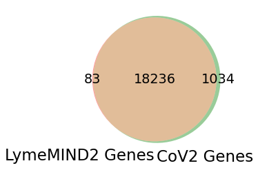

```python
common_genes = list(set(df_lm2_gene_expression.index) & set(df_cov_gene_expression.index))
venn2([
    set(df_lm2_gene_expression.index),
    set(df_cov_gene_expression.index),
], [
    'LymeMIND2 Genes',
    'CoV2 Genes',
])

# Normalize then merge data

df_cov_gene_expression_norm = quantile_normalize(
  zscore_normalize(
    np.log2(
      df_cov_gene_expression[df_cov_gene_expression.mean(axis=1)>5] + 1
    )
  )
)

df_lm2_gene_expression_norm = quantile_normalize(
  zscore_normalize(
    np.log2(
      df_lm2_gene_expression[df_lm2_gene_expression.mean(axis=1)>5] + 1
    )
  )
)

df_cov_gene_expression_norm
df_merged_gene_expression_norm = merge(df_cov_gene_expression_norm, df_lm2_gene_expression_norm, how='inner')

df_merged_gene_expression_norm_batch_corrected = pd.DataFrame(
    r['ComBat'](
        dat=r['as.matrix'](df_merged_gene_expression_norm.loc[:, list(df_meta.index)]),
        batch=df_meta['Dataset'] # design
    ),
    index=df_merged_gene_expression_norm.index,
    columns=list(df_meta.index),
)
```

## Classification performance

```python
def plot_performance(y, y_probas, title=None, legend_ratio=0.25, legend_padding=0.05):
  fig, (ax1, ax2) = plt.subplots(1, 2, figsize=(18, 9))
  ax1.set_title('Receiver Operation Characteristic')
  ax1.set_xlabel('False Positive Rate')
  ax1.set_ylabel('True Positive Rate')
  ax1.set_ylim((-0.05, 1.05))
  for model, y_proba in y_probas:
    fpr, tpr, _ = roc_curve(y, y_proba)
    roc_auc = auc(fpr, tpr)
    ax1.plot(fpr, tpr, label=f"{model} (AUC: {roc_auc:.3f})")
  ax1.legend(loc="lower center", bbox_to_anchor=(0.5, -legend_ratio - legend_padding), prop={'size': 16})
  ax2.set_title('Precision Recall')
  ax2.set_ylabel('Precision')
  ax2.set_xlabel('Recall')
  ax2.set_ylim((-0.05, 1.05))
  for model, y_proba in y_probas:
    prec, rec, _ = precision_recall_curve(y, y_proba)
    pr_auc = auc(rec, prec)
    ax2.plot(rec, prec, label=f"{model} (AUC: {pr_auc:.3f})", drawstyle='steps-post')
  ax2.legend(loc="lower center", bbox_to_anchor=(0.5, -legend_ratio - legend_padding), prop={'size': 16})
  fig.subplots_adjust(bottom=legend_ratio)
  if title is not None:
    fig.suptitle(title, fontsize=22)
  return fig
```

### Figure 7.A: Controls v Cases

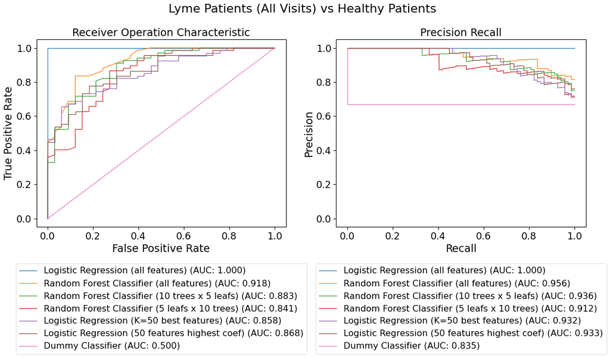

```python
X = np.log2(df_lm2_gene_expression.loc[:].T+1)
y = df_lm2_clinical.loc[:, 'type_subject'].astype(int)

X_train, X_test, y_train, y_test = train_test_split(X, y, random_state=42, stratify=y)

models = [
  (
    'Logistic Regression (all features)',
    LogisticRegressionCV(),
  ),
  (
    'Random Forest Classifier (all features)',
    RandomForestClassifier(random_state=42),
  ),
  (
    'Random Forest Classifier (10 trees x 5 leafs)',
    RandomForestClassifier(random_state=42, max_leaf_nodes=5, n_estimators=10)
  ),
  (
    'Random Forest Classifier (5 leafs x 10 trees)',
    RandomForestClassifier(random_state=42, max_leaf_nodes=10, n_estimators=5)
  ),
  (
    'Logistic Regression (K=50 best features)',
    Pipeline([
      ('selection', SelectKBest(k=50)),
      ('classification', LogisticRegressionCV()),
    ])
  ),
  (
    'Logistic Regression (50 features highest coef)',
    Pipeline([
      ('selection', SelectFromModel(LogisticRegressionCV(), max_features=50)),
      ('classification', LogisticRegressionCV()),
    ])
  ),
  (
    'Dummy Classifier',
    DummyClassifier(random_state=42)
  ),
]

scaler = StandardScaler()
scaler.fit(X_train)
for _, model in models:
  model.fit(
    scaler.transform(X_train) if scaler else X_train,
    y_train
  )

plot_performance(y_test, [
  (
    label,
    model.predict_proba(
      scaler.transform(X_test) if scaler else X_test
    )[:, 1]
  )
  for label, model in models
],
  title='Lyme Patients (All Visits) vs Healthy Patients',
  legend_ratio=0.35,
  legend_padding=0.35,
).show()
```

### Figure 7.B Lyme v PTLDS

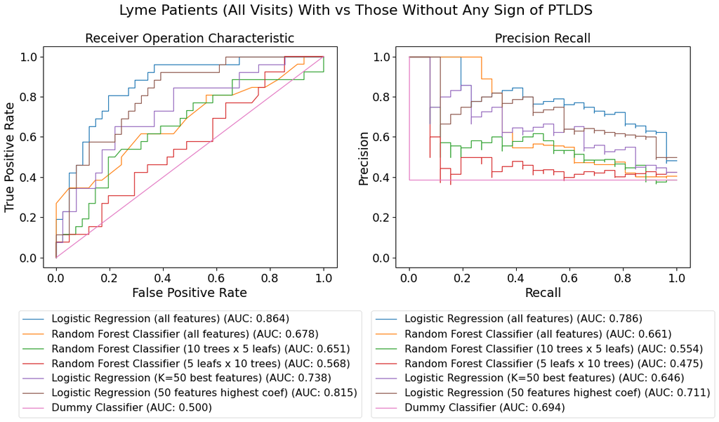

```python
samples = list(df_lm2_clinical[df_lm2_clinical['type_subject'] == 1].index)
X = np.log2(df_lm2_gene_expression.loc[:, samples].T+1)
y = df_lm2_clinical.loc[samples, 'ptlds_anysign'].astype(int)

X_train, X_test, y_train, y_test = train_test_split(X, y, random_state=42, stratify=y)

models = [
  (
    'Logistic Regression (all features)',
    LogisticRegressionCV(),
  ),
  (
    'Random Forest Classifier (all features)',
    RandomForestClassifier(random_state=42),
  ),
  (
    'Random Forest Classifier (10 trees x 5 leafs)',
    RandomForestClassifier(random_state=42, max_leaf_nodes=5, n_estimators=10)
  ),
  (
    'Random Forest Classifier (5 leafs x 10 trees)',
    RandomForestClassifier(random_state=42, max_leaf_nodes=10, n_estimators=5)
  ),
  (
    'Logistic Regression (K=50 best features)',
    Pipeline([
      ('selection', SelectKBest(k=50)),
      ('classification', LogisticRegressionCV()),
    ])
  ),
  (
    'Logistic Regression (50 features highest coef)',
    Pipeline([
      ('selection', SelectFromModel(LogisticRegressionCV(), max_features=50)),
      ('classification', LogisticRegressionCV()),
    ])
  ),
  (
    'Dummy Classifier',
    DummyClassifier(random_state=42)
  ),
]

scaler = StandardScaler()
scaler.fit(X_train)
for _, model in models:
  model.fit(
    scaler.transform(X_train) if scaler else X_train,
    y_train
  )

plot_performance(y_test, [
  (
    label,
    model.predict_proba(
      scaler.transform(X_test) if scaler else X_test
    )[:, 1]
  )
  for label, model in models
],
  title='Lyme Patients (All Visits) With vs Those Without Any Sign of PTLDS',
  legend_ratio=0.35,
  legend_padding=0.35,
).show()
```

### Figure 7.C: Lyme with CIBERSORT

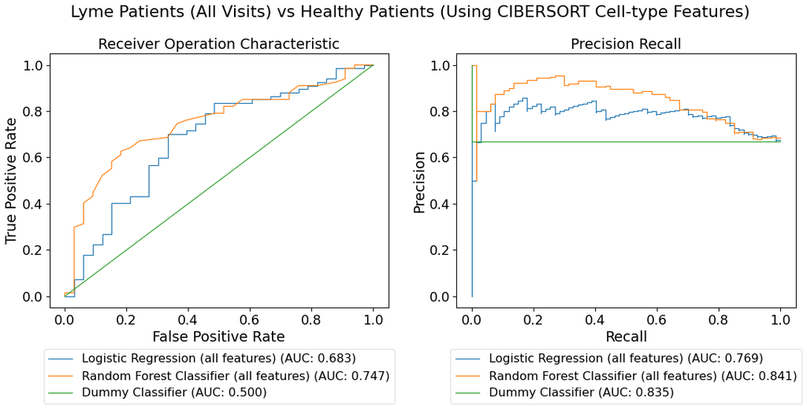

```python
X = df_lm2_cibersort
y = df_lm2_clinical.loc[:, 'type_subject'].astype(int)

X_train, X_test, y_train, y_test = train_test_split(X, y, random_state=42, stratify=y)

models = [
  (
    'Logistic Regression (all features)',
    LogisticRegressionCV(),
  ),
  (
    'Random Forest Classifier (all features)',
    RandomForestClassifier(random_state=42),
  ),
  (
    'Dummy Classifier',
    DummyClassifier(random_state=42)
  ),
]

scaler = StandardScaler()
scaler.fit(X_train)
for _, model in models:
  model.fit(
    scaler.transform(X_train) if scaler else X_train,
    y_train
  )

plot_performance(y_test, [
  (
    label,
    model.predict_proba(
      scaler.transform(X_test) if scaler else X_test
    )[:, 1]
  )
  for label, model in models
],
  title='Lyme Patients (All Visits) vs Healthy Patients (Using CIBERSORT Cell-type Features)',
  legend_ratio=0.35,
  legend_padding=0.05,
).show()
```

### Figure 7.D: PTLDS with CIBERSORT

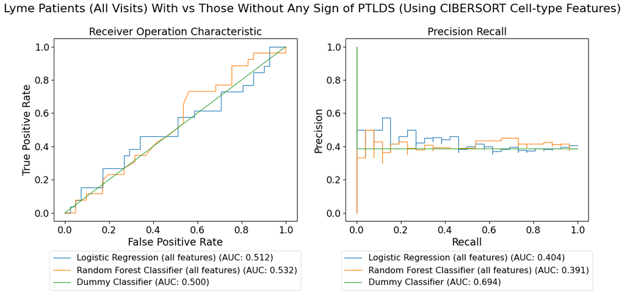

```python
samples = list(df_lm2_clinical[df_lm2_clinical['type_subject'] == 1].index)
X = df_lm2_cibersort.loc[samples]
y = df_lm2_clinical.loc[samples, 'ptlds_anysign'].astype(int)

X_train, X_test, y_train, y_test = train_test_split(X, y, random_state=42, stratify=y)

models = [
  (
    'Logistic Regression (all features)',
    LogisticRegressionCV(),
  ),
  (
    'Random Forest Classifier (all features)',
    RandomForestClassifier(random_state=42),
  ),
  (
    'Dummy Classifier',
    DummyClassifier(random_state=42)
  ),
]

scaler = StandardScaler()
scaler.fit(X_train)
for _, model in models:
  model.fit(
    scaler.transform(X_train) if scaler else X_train,
    y_train
  )

plot_performance(y_test, [
  (
    label,
    model.predict_proba(
      scaler.transform(X_test) if scaler else X_test
    )[:, 1]
  )
  for label, model in models
],
  title='Lyme Patients (All Visits) With vs Those Without Any Sign of PTLDS (Using CIBERSORT Cell-type Features)',
  legend_ratio=0.35,
  legend_padding=0.05,
).show()
```

### Figure 7.E: LM2 vs COV

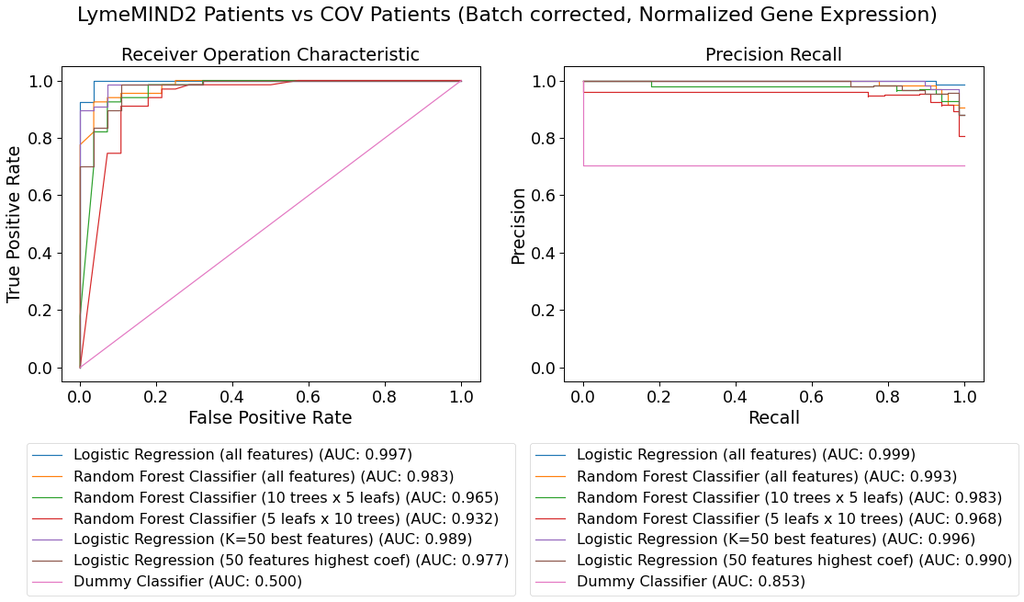

```python
lyme_v_cov_samples = df_meta[np.in1d(df_meta['Condition'], ['Lyme Patient', 'COV'])].index
early_visit_samples = df_lm2_clinical[np.in1d(df_lm2_clinical['visit'], [1,2,3])].index
samples = list(set(lyme_v_cov_samples) | set(early_visit_samples))

X = df_merged_gene_expression_norm.loc[:, samples].T
y = (df_meta.loc[samples, 'Condition'] == 'Lyme Patient').astype(int)

X_train, X_test, y_train, y_test = train_test_split(X, y, random_state=42, stratify=y)

models = [
  (
    'Logistic Regression (all features)',
    LogisticRegressionCV(),
  ),
  (
    'Random Forest Classifier (all features)',
    RandomForestClassifier(random_state=42),
  ),
  (
    'Random Forest Classifier (10 trees x 5 leafs)',
    RandomForestClassifier(random_state=42, max_leaf_nodes=5, n_estimators=10)
  ),
  (
    'Random Forest Classifier (5 leafs x 10 trees)',
    RandomForestClassifier(random_state=42, max_leaf_nodes=10, n_estimators=5)
  ),
  (
    'Logistic Regression (K=50 best features)',
    Pipeline([
      ('selection', SelectKBest(k=50)),
      ('classification', LogisticRegressionCV()),
    ])
  ),
  (
    'Logistic Regression (50 features highest coef)',
    Pipeline([
      ('selection', SelectFromModel(LogisticRegressionCV(), max_features=50)),
      ('classification', LogisticRegressionCV()),
    ])
  ),
  (
    'Dummy Classifier',
    DummyClassifier(random_state=42)
  ),
]

scaler = StandardScaler()
scaler.fit(X_train)
for _, model in models:
  model.fit(
    scaler.transform(X_train) if scaler else X_train,
    y_train
  )

plot_performance(y_test, [
  (
    label,
    model.predict_proba(
      scaler.transform(X_test) if scaler else X_test
    )[:, 1]
  )
  for label, model in models
],
  title='LymeMIND2 Patients vs COV Patients (Batch corrected, Normalized Gene Expression)',
  legend_ratio=0.35,
  legend_padding=0.35,
)
plt.show()
```